# LCCS_preparacao

aniellima

2022-11-01

```r
library(tidyverse)
library(terra)
library(raster)
library(rasterVis)
library(stars)
library(sf)
library(rgdal)
library(diffeR)
library(ncdf4)
```

```r
r92 <-rast("../rawData/landcover/global/ESACCI-LC-L4-LCCS-Map-300m-P1Y-1992-v2.0.7cds.nc")
r00 <- rast("../rawData/landcover/global/ESACCI-LC-L4-LCCS-Map-300m-P1Y-2000-v2.0.7cds.nc")
r05 <- rast("../rawData/landcover/global/ESACCI-LC-L4-LCCS-Map-300m-P1Y-2005-v2.0.7cds.nc")
r10 <- rast("../rawData/landcover/global/ESACCI-LC-L4-LCCS-Map-300m-P1Y-2010-v2.0.7cds.nc")
r15 <- rast("../rawData/landcover/global/ESACCI-LC-L4-LCCS-Map-300m-P1Y-2015-v2.0.7cds.nc")
r20 <- rast("../rawData/landcover/global/C3S-LC-L4-LCCS-Map-300m-P1Y-2020-v2.1.1.nc")
```

```r
names(r00)
```

```
## [1] "lccs_class"          "processed_flag"      "current_pixel_state"
## [4] "observation_count"   "change_count"
```

```r
lc92 <- r92[[1]]
lc00 <- r00[[1]]
lc05 <- r05[[1]]
lc10 <- r10[[1]]
lc15 <- r15[[1]]
lc20 <- r20[[1]]
```

```r
lc92<-raster(lc92)
names(lc92) = "lccs92"
lc00<-raster(lc00)
names(lc00) = "lccs00"
lc05<-raster(lc05)
names(lc05) = "lccs05"
lc10<-raster(lc10)
names(lc10) = "lccs10"
lc15<-raster(lc15)
names(lc15) = "lcc15"
lc20<-raster(lc20)
names(lc20) = "lccs20"
```

```r
globalLC <- stack(lc92,lc00,lc05,lc10,lc15,lc20)
```

```r
names(globalLC )
```

```
## [1] "lccs92" "lccs00" "lccs05" "lccs10" "lcc15"  "lccs20"
```

```r
tianShanOutShp<-sf::st_read("../processedData/shp/tianshan/tianShanOutter.shp")
tianShanShp<-tianShanOutShp
# crop
tianS.crop <- crop(globalLC, extent(tianShanShp))
# mask
tianShanLC<- mask(tianS.crop, tianShanShp)
```

- Frequencia contagem de celulas com uso de solo urbano por periodo

```r
names(tianShanLC)
```

```
## [1] "lccs92" "lccs00" "lccs05" "lccs10" "lcc15"  "lccs20"
```

```r
# Calcula a frequencia por Layer(periodo)
freq92<-freq(tianShanLC[[1]])
freq00<-freq(tianShanLC[[2]])
freq05<-freq(tianShanLC[[3]])
freq10<-freq(tianShanLC[[4]])
freq15<-freq(tianShanLC[[5]])
freq20<-freq(tianShanLC[[6]])

#Unifica os bancos e o transforma em df.
freq<-cbind(freq92,freq00,freq05,freq10,freq15,freq20)%>%as_tibble()
names(freq)
```

```
##  [1] "value" "count" "V3"    "V4"    "V5"    "V6"    "V7"    "V8"    "V9"
## [10] "V10"   "V11"   "V12"
```

```r
#Seleciona e renomeia varáveis de interesse:
freq<-freq%>%dplyr::select(1,2,4,6,8,10,12)%>%rename("1992"=count,
                                               "2000"=V4,
                                               "2005"=V6,
                                               "2010"=V8,
                                               "2015"=V10,
                                               "2020"=V12)
```

```r
names(freq)
```

```
## [1] "value" "1992"  "2000"  "2005"  "2010"  "2015"  "2020"
```

```r
#Transforma em longo
freq<-freq%>%dplyr::select(value,`1992`,`2000`,`2005`,`2010`,`2015`,`2020`)%>%pivot_longer(cols=c(`1992`,`2000`,`2005`,`2010`,`2015`,`2020`), names_to="Ano", values_to="Pixels")

#Transforma categorias em variável categórica
freq$value <- as.character(freq$value)

#renomeia value para lccs
freq<-freq%>%rename(lccs=value)# transform lccs em categoria

#ordena por anos
freq<-freq%>%mutate(Ano=fct_relevel(Ano, "1992", "2000", "2005", "2010", "2015", "2020"))
```

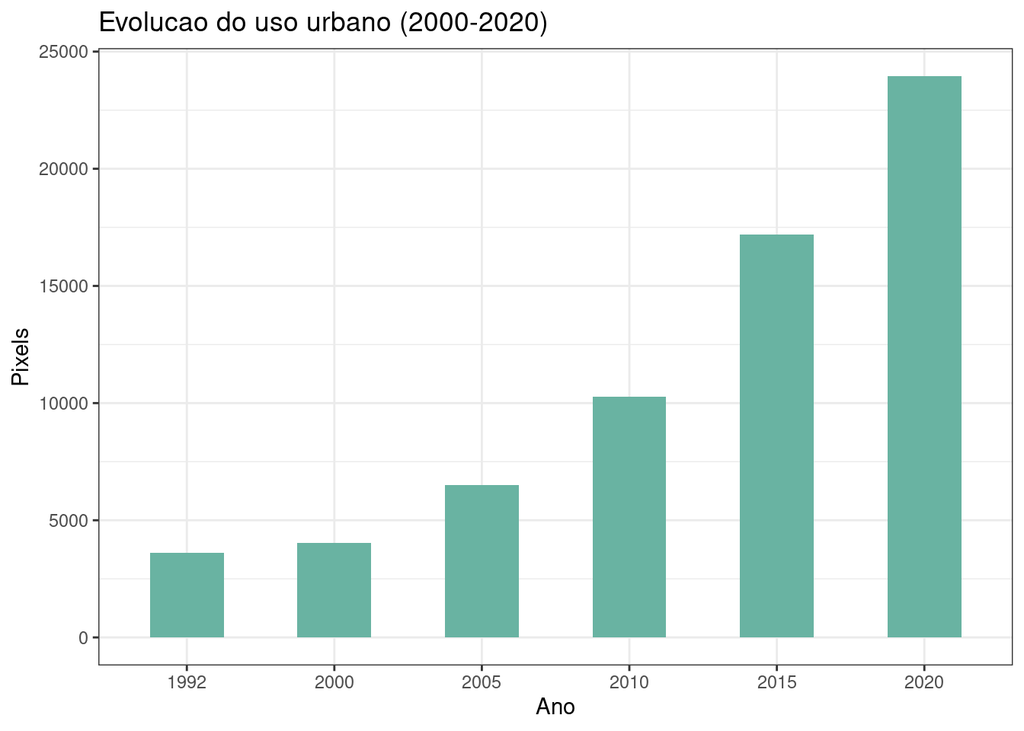

```r
# filtra e projeta quantidade de área de uso urbano
urbanG<-freq%>%filter(lccs=="190")%>%ggplot(aes(x=Ano, y=Pixels))+geom_bar(stat="identity", width=0.5, fill="#69b3a2")+theme_bw()+ ggtitle("Evolucao do uso urbano (2000-2020)")
urbanG
```

```r
urbanT<-freq%>%filter(lccs=="190")
urbanT
```

```
## # A tibble: 6 × 3
##   lccs  Ano   Pixels
##   <chr> <fct>  <dbl>
## 1 190   1992    3595
## 2 190   2000    4016
## 3 190   2005    6501
## 4 190   2010   10283
## 5 190   2015   17209
## 6 190   2020   23950
```

- Como o grafico e a tabela acima demontram, a varicao de Pixels entre 1992 e 2000 é baixa. Apesar de terem sido neste ano que as Zonas Economicas foram criadas. Aparentemente nota-se aumento expresico no uso do solo urbano apena a partir de 2005, quando já haviam se passado cinco anos desde o lancamento das politicas de desenvovivimento do Oeste. Esta tendencia de aumento da cobertura urbana se acentua nos anos seguintes e em 2020 a quantidade Pixels é de 23.950, mais de seis vezs o quantitativo apurado em 1992.

```r
#idetifica as categorias em cada layer
cat92<-unique(tianShanLC[[1]])%>%tibble()
cat00<-unique(tianShanLC[[2]])%>%tibble()
cat05<-unique(tianShanLC[[3]])%>%tibble()
cat10<-unique(tianShanLC[[4]])%>%tibble()
cat15<-unique(tianShanLC[[5]])%>%tibble()
cat20<-unique(tianShanLC[[6]])%>%tibble()

#verifica se as mesmas categorias existem para os 4 layers.
cbind(cat92,cat00,cat05,cat10,cat15,cat20)
```

```
##      .   .   .   .   .   .
## 1   10  10  10  10  10  10
## 2   11  11  11  11  11  11
## 3   20  20  20  20  20  20
## 4   30  30  30  30  30  30
## 5   40  40  40  40  40  40
## 6   60  60  60  60  60  60
## 7   70  70  70  70  70  70
## 8   80  80  80  80  80  80
## 9  100 100 100 100 100 100
## 10 110 110 110 110 110 110
## 11 120 120 120 120 120 120
## 12 130 130 130 130 130 130
## 13 150 150 150 150 150 150
## 14 180 180 180 180 180 180
## 15 190 190 190 190 190 190
## 16 200 200 200 200 200 200
## 17 201 201 201 201 201 201
## 18 202 202 202 202 202 202
## 19 210 210 210 210 210 210
## 20 220 220 220 220 220 220
```

- Importa a tabela de categorias, códigos e cores dos arquivos documentation disponíveis no portal do [CDS](https://cds.climate.copernicus.eu/cdsapp#!/dataset/satellite-land-cover?tab=doc)

```r
lccsCodes<- read_delim("../rawData/landcover/lccsCodes.csv", col_types = "iiccccc")#importa tabela csv identificado o tipos de variáveis
```

```r
names(lccsCodes)
```

```
## [1] "lccs_class"      "global_code"     "land_cover"      "color_code"
## [5] "IPCC_class"      "IPCC_color_code"
```

```r
lccsCodes %>% distinct(global_code,IPCC_class,IPCC_color_code)
```

```
## # A tibble: 23 × 3
##    global_code IPCC_class  IPCC_color_code
##          <int> <chr>       <chr>
##  1          10 Agriculture #ffff64
##  2          20 Agriculture #ffff64
##  3          30 Agriculture #ffff64
##  4          40 Agriculture #ffff64
##  5          50 Forest      #006400
##  6          60 Forest      #006400
##  7          70 Forest      #006400
##  8          80 Forest      #006400
##  9          90 Forest      #006400
## 10         100 Forest      #006400
## # … with 13 more rows
```

```r
lccsCodes %>% distinct(IPCC_class,IPCC_color_code)
```

```
## # A tibble: 8 × 2
##   IPCC_class              IPCC_color_code
##   <chr>                   <chr>
## 1 Agriculture             #ffff64
## 2 Forest                  #006400
## 3 Grassland               #C6CC51
## 4 Others                  #dcdcdc
## 5 Wetland                 #4d8784
## 6 Urban areas             #FF0000
## 7 Bare areas(added by me) #fff5d7
## 8 Water bodies            #2E86C1
```

```r
colors<-lccsCodes %>% dplyr::select(lccs_class,IPCC_class,IPCC_color_code)
colors<-colors %>% rename(ID=lccs_class,color=IPCC_color_code)
```

- precisamos tranformar nossas varivel dentro do arquivo raster em categorica. Para tanto utilizamos da fucao ratify do pacote **raster**

```r
# precisamos tranformar Use ratify to transform lccs00 in categorical
lc92 = ratify(tianShanLC[[1]])
lc00 = ratify(tianShanLC[[2]])
lc05 = ratify(tianShanLC[[3]])
lc10 = ratify(tianShanLC[[4]])
lc15 = ratify(tianShanLC[[5]])
lc20 = ratify(tianShanLC[[6]])
```

- Verificamos anteriormente que embora nosso recorte contenha menos categorias que o total presente no globo, entre os 6 periodos em questao as categorias nao variam para o recorte. Por isso é seguro criar um objeto chamado cat a partir de qualquer dos layers, transforma-lo em e fazer um left join com o df de cores.

```r
cat<-levels(lc92)%>%data.frame()

colors<-cat %>% left_join(colors, by="ID")
csort = colors %>% arrange(ID)
csort = colors[order(colors$ID),]
```

[output not shown]

- Muito embora nossas categorias tenham sido classificadas como fatores ordenados, o fato de serem representadas por “numeros” podem gerar confusão. Sendo assim, vamos incluir uma outra variavel para que as categorias estejam sejam de fato concebidas com “strings”.

```r
# create variable with string for code starting with LC-
levels(lc92)[[1]]$code = paste0("LC-",levels(lc92)[[1]]$ID)
levels(lc00)[[1]]$code = paste0("LC-",levels(lc00)[[1]]$ID)
levels(lc05)[[1]]$code = paste0("LC-",levels(lc05)[[1]]$ID)
levels(lc10)[[1]]$code = paste0("LC-",levels(lc10)[[1]]$ID)
levels(lc15)[[1]]$code = paste0("LC-",levels(lc15)[[1]]$ID)
levels(lc20)[[1]]$code = paste0("LC-",levels(lc20)[[1]]$ID)
```

- Por fim, juntamos todos os nossos layer em um só raster.

```r
tianShanLC <- stack(lc92,lc00,lc05,lc10,lc15,lc20)
```

- Podemos projeta-los de uma só vez como o levelplot do pacote lattice

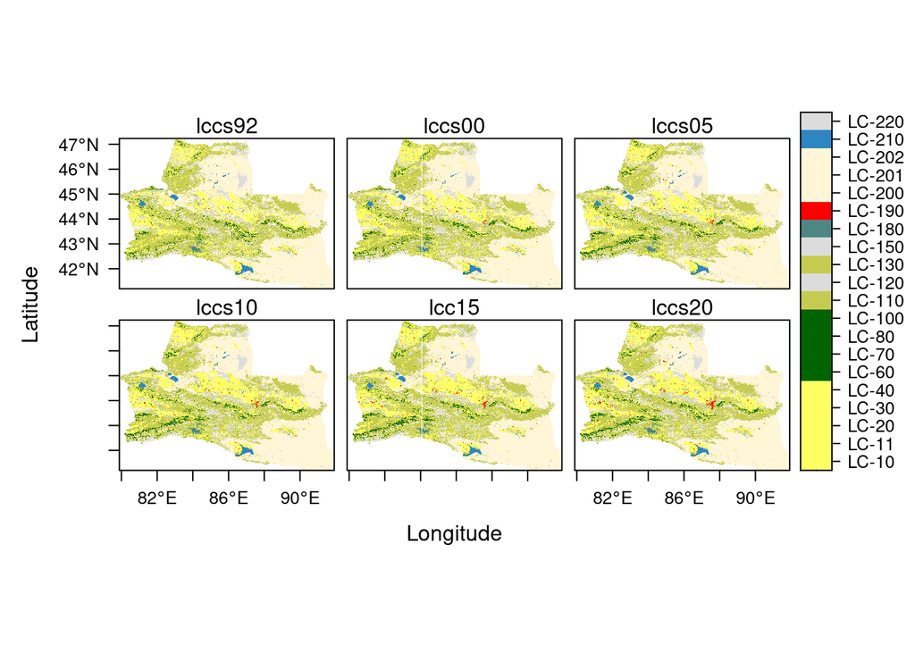

```r
levelplot(tianShanLC,col.regions=csort$color)
```

- Ou fazer projecoes comparativas como esse que para os anos de 1992 e 2020

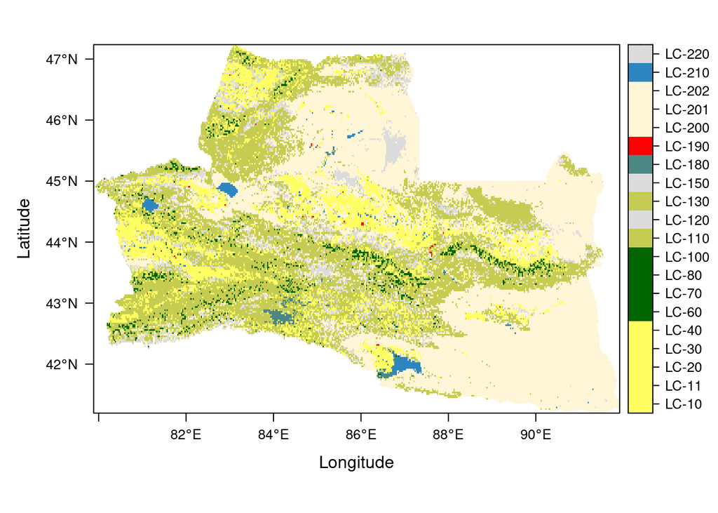

```r
levelplot(tianShanLC[[1]],col.regions=csort$color)
```

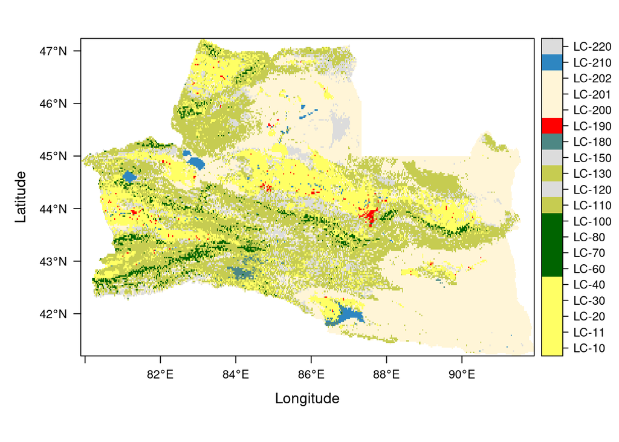

```r
levelplot(tianShanLC[[6]],col.regions=csort$color)
```

- Vamos visualizar novamente esse contratra a partir de uma gráfico:

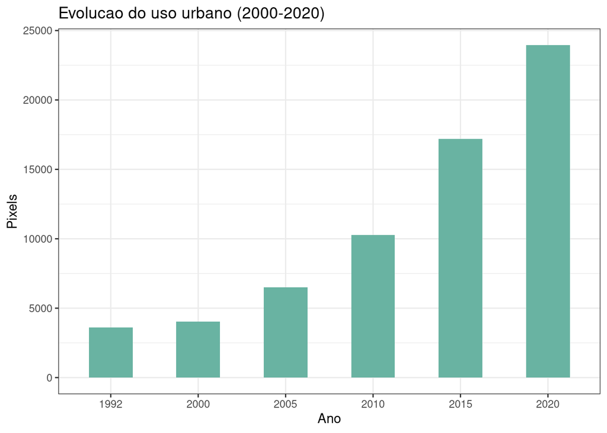

```r
urbanG
```

- Vamos salvar nossa base em tiff.

```r
writeRaster(tianShanLC, "../rawData/landcover/tianshan/tianshan.tif", overwrite=TRUE)
```

- Agora vamos verificar a disposicão do uso urbando por cidade e distrito nesse mesmo recorte.